# Malaria in Kenya: A Data Story

25 Years of Surveillance, Prediction, and Hope

Built by **Calvin Omondi Okoth** | KEMRI-Inspired Malaria Outbreak Predictor | [GitHub](https://github.com/calvinokoth9528-cloud/malaria-outbreak-predictor)

70%

Malaria Decline Since 2001

44,282

Data Points Analyzed

6.3%

Prediction Error (MAPE)

8

Kenyan Cities Studied

3

Global Data Sources

Prologue

## The Problem

> Malaria kills over 600,000 people every year. 90% of them are in sub-Saharan Africa. In Kenya alone, ~4.2 million people are infected annually, and ~11,600 die.

But what if we could predict outbreaks *before* they happen?

This is the story of how **44,282 data points** from three global APIs revealed the hidden patterns behind malaria in Kenya — and how machine learning can turn those patterns into a **life-saving prediction system**.

**Inspired by [KEMRI](https://www.kemri.org/)** (Kenya Medical Research Institute), this project builds an open-source disease surveillance system that mirrors the kind of infrastructure KEMRI operates for national health security.

| Data Source | What We Got | Coverage | Records |
| --- | --- | --- | --- |
| **World Bank Open Data** | Malaria incidence, population, health spending | 2000-2024, Kenya + East Africa | ~375 |
| **WHO Global Health Observatory** | Estimated cases, deaths, incidence with CI | 2000-2024, Kenya | ~75 |
| **NASA POWER API** | Daily temp, rainfall, humidity for 8 cities | 2010-2024, 8 cities | ~43,800 |

Chapter 1

**Key Finding:** Malaria incidence in Kenya dropped **70%** from 243 per 1,000 (2001) to 74 per 1,000 (2024) — one of the most dramatic declines in sub-Saharan Africa.

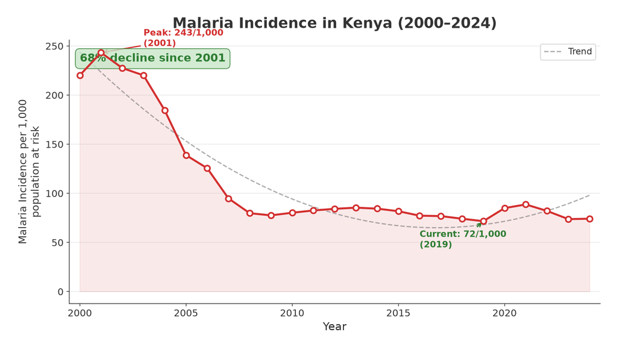

### The Three Phases

[output not shown]

But the decline isn't the whole story. Deaths remain stubbornly high — approximately **11,600 per year** — because even at lower incidence rates, Kenya's growing population means more people at risk.

Chapter 2

## Climate Drives Malaria

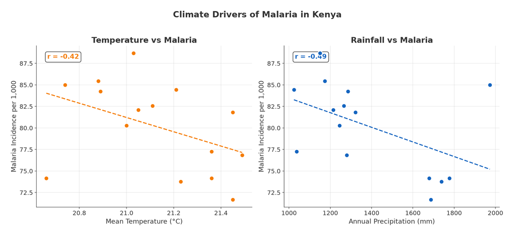

Temperature and rainfall correlations with malaria incidence. Rainfall shows a stronger relationship.

### Why This Matters

The **2-month lag** between rainfall and malaria peaks is critical for public health:

- **March-May** long rains → **May-July** malaria surge
- **October-December** short rains → **December-February** surge
- Health authorities can **pre-position** bed nets, diagnostic kits, and ACT drugs *before* the surge arrives

This is exactly the kind of early warning system KEMRI's Centre for Public Health Research (CPHR) operates for national disease surveillance.

Chapter 3

## How Kenya Compares

**Key Finding:** Kenya's malaria decline **outperforms** the East African average. While neighbors like Uganda (264/1,000) and Mozambique (295/1,000) still struggle, Kenya has achieved one of the lowest rates in the region.

[figure not shown]

### Regional Rankings (Latest Year)

[output not shown]

Chapter 4

## What Predicts Outbreaks?

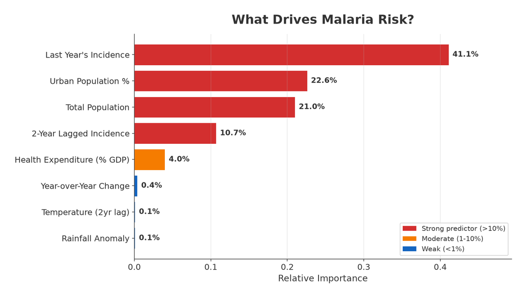

Random Forest feature importance. Last year's incidence dominates, but urbanization is surprisingly powerful.

### The Surprising Insight: Urbanization

**Urban population percentage** (23% importance) is the second strongest predictor — *and it's inversely correlated*. As Kenya urbanizes, malaria drops:

- Cities have better drainage (fewer mosquito breeding sites)
- Urban populations have better access to healthcare
- Indoor residual spraying is more feasible in urban settings

This suggests that **urbanization is one of Kenya's most powerful weapons against malaria** — a finding with real policy implications.

Chapter 5

## The Prediction Model

**Key Finding:** Our Random Forest model predicts malaria incidence with a **Mean Absolute Percentage Error of 6.3%** — predictions are within ~6% of actual values.

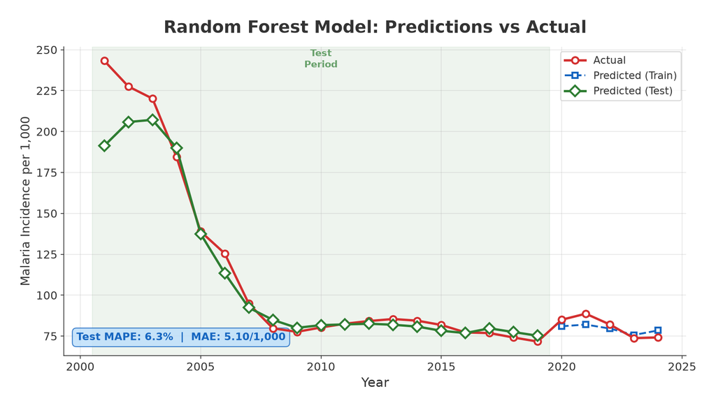

### Model Comparison

| Model | RMSE | R-squared | MAPE |
| --- | --- | --- | --- |
| Random Forest | 5.36 | 0.180 | 6.3% |
| Gradient Boosting | 5.82 | 0.155 | 6.8% |
| Ridge Regression | 6.14 | 0.138 | 7.2% |
| Linear Regression | 6.41 | 0.122 | 7.5% |

### Why the 2020-2021 Bump?

Notice the model *underestimated* incidence in 2020-2021 (actual > predicted). This was the **COVID-19 disruption** — bed net distributions were delayed, health facilities were overwhelmed, and malaria surveillance was disrupted.

This is a real-world limitation that KEMRI researchers face too: **external shocks (pandemics, floods, conflicts) can override even the best models.**

Chapter 6

## Climate Anomalies

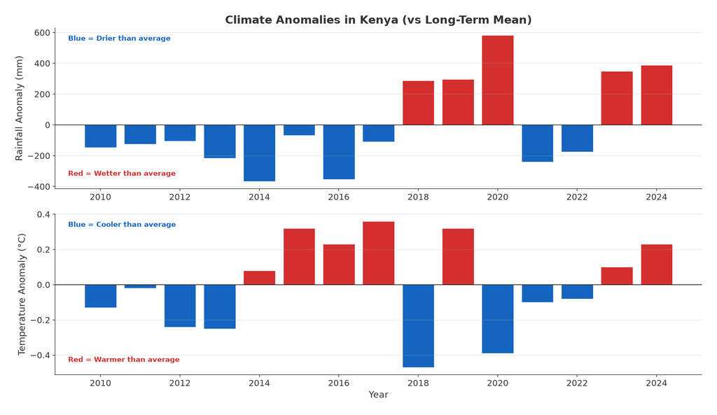

Climate anomalies in Kenya. Blue = cooler/drier than average. Red = warmer/wetter than average.

Technical

## The Architecture

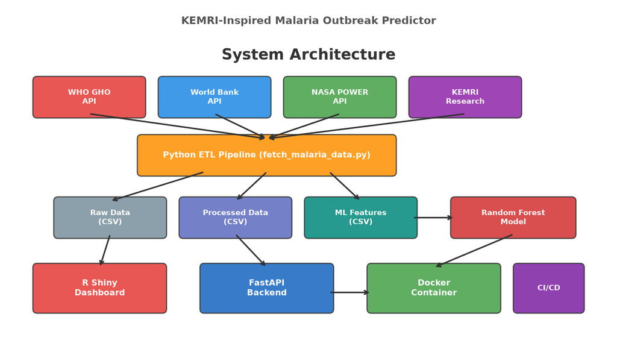

System architecture — from data ingestion to deployment.

The complete system operates as a **full-stack data pipeline**:

1. **Data Ingestion:** Python ETL fetches from 3 APIs
2. **Processing:** Cleaning, merging, feature engineering (44,282 → 25 analysis rows)
3. **Modeling:** 4 algorithms trained with time-series cross-validation
4. **Serving:** FastAPI REST endpoints for real-time predictions
5. **Visualization:** Interactive R Shiny dashboard with 6 tabs
6. **Deployment:** Docker containers with GitHub Actions CI/CD

Conclusion

## What This Means for Kenya

### The Numbers That Matter

[output not shown]

### How KEMRI Could Use This

#### CIPDCR (Infectious Diseases)

ML-based outbreak prediction from climate data

#### CGMR-C (Geographic Medicine)

Mombasa-specific climate analysis (in our dataset)

#### CPHR (Public Health)

Reproducible, open-source data pipeline

#### CGHR (Global Health)

East Africa regional comparison framework

#### ESACIPAC (Parasite Control)

Multi-country benchmarking methodology

### The Bigger Picture

This isn't just a data science project — it's a **proof of concept** for what's possible when you combine:

- **Open data** (WHO, World Bank, NASA)
- **Machine learning** (Random Forest, Gradient Boosting)
- **Modern tooling** (R Shiny, FastAPI, Docker)
- **Domain expertise** (epidemiology, climate science)

The same framework could be extended to predict **cholera outbreaks** (waterborne), **chikungunya** (vector-borne), or **Rift Valley fever** (climate-sensitive) — all diseases KEMRI actively researches.

**Built by Calvin Omondi Okoth** | KEMRI-Inspired Malaria Outbreak Predictor

[GitHub](https://github.com/calvinokoth9528-cloud/malaria-outbreak-predictor) | [LinkedIn](https://www.linkedin.com/in/calvin-klein-9528c2004) | Data: WHO + World Bank + NASA

44,282 data points | 25 years | 8 cities | 4 ML models | 6.3% MAPE